# **Problem Statement**

#### **Business Context**

Understanding customer personality and behavior is pivotal for businesses to enhance customer satisfaction and increase revenue. Segmentation based on a customer's personality, demographics, and purchasing behavior allows companies to create tailored marketing campaigns, improve customer retention, and optimize product offerings.

A leading retail company with a rapidly growing customer base seeks to gain deeper insights into their customers' profiles. The company recognizes that understanding customer personalities, lifestyles, and purchasing habits can unlock significant opportunities for personalizing marketing strategies and creating loyalty programs. These insights can help address critical business challenges, such as improving the effectiveness of marketing campaigns, identifying high-value customer groups, and fostering long-term relationships with customers.

With the competition intensifying in the retail space, moving away from generic strategies to more targeted and personalized approaches is essential for sustaining a competitive edge.

#### **Objective**

In an effort to optimize marketing efficiency and enhance customer experience, the company has embarked on a mission to identify distinct customer segments. By understanding the characteristics, preferences, and behaviors of each group, the company aims to:

1. Develop personalized marketing campaigns to increase conversion rates.
2. Create effective retention strategies for high-value customers.
3. Optimize resource allocation, such as inventory management, pricing strategies, and store layouts.

As a data scientist tasked with this project, your responsibility is to analyze the given customer data, apply machine learning techniques to segment the customer base, and provide actionable insights into the characteristics of each segment.

#### **Data Dictionary**

The dataset includes historical data on customer demographics, personality traits, and purchasing behaviors. Key attributes are:

1. **Customer Information**
   - **ID:** Unique identifier for each customer.
   - **Year_Birth:** Customer's year of birth.
   - **Education:** Education level of the customer.
   - **Marital_Status:** Marital status of the customer.
   - **Income:** Yearly household income (in dollars).
   - **Kidhome:** Number of children in the household.
   - **Teenhome:** Number of teenagers in the household.
   - **Dt_Customer:** Date when the customer enrolled with the company.
   - **Recency:** Number of days since the customer’s last purchase.
   - **Complain:** Whether the customer complained in the last 2 years (1 for yes, 0 for no).
2. **Spending Information (Last 2 Years)**
   - **MntWines:** Amount spent on wine.
   - **MntFruits:** Amount spent on fruits.
   - **MntMeatProducts:** Amount spent on meat.
   - **MntFishProducts:** Amount spent on fish.
   - **MntSweetProducts:** Amount spent on sweets.
   - **MntGoldProds:** Amount spent on gold products.
3. **Purchase and Campaign Interaction**
   - **NumDealsPurchases:** Number of purchases made using a discount.
   - **AcceptedCmp1:** Response to the 1st campaign (1 for yes, 0 for no).
   - **AcceptedCmp2:** Response to the 2nd campaign (1 for yes, 0 for no).
   - **AcceptedCmp3:** Response to the 3rd campaign (1 for yes, 0 for no).
   - **AcceptedCmp4:** Response to the 4th campaign (1 for yes, 0 for no).
   - **AcceptedCmp5:** Response to the 5th campaign (1 for yes, 0 for no).
   - **Response:** Response to the last campaign (1 for yes, 0 for no).
4. **Shopping Behavior**
   - **NumWebPurchases:** Number of purchases made through the company’s website.
   - **NumCatalogPurchases:** Number of purchases made using catalogs.
   - **NumStorePurchases:** Number of purchases made directly in stores.
   - **NumWebVisitsMonth:** Number of visits to the company’s website in the last month.

```python
from google.colab import drive
drive.mount('/content/drive')
```

# **Let's start coding!**

## **Importing necessary libraries**

```python
# Libraries to help with reading and manipulating data
import pandas as pd
import numpy as np

# libaries to help with data visualization
import matplotlib.pyplot as plt
import seaborn as sns

# Removes the limit for the number of displayed columns
pd.set_option("display.max_columns", None)
# Sets the limit for the number of displayed rows
pd.set_option("display.max_rows", 200)

# to scale the data using z-score
from sklearn.preprocessing import StandardScaler

# to compute distances
from scipy.spatial.distance import cdist, pdist

# to perform k-means clustering and compute silhouette scores
from sklearn.cluster import KMeans
from sklearn.metrics import silhouette_score

# to visualize the elbow curve and silhouette scores
from yellowbrick.cluster import KElbowVisualizer, SilhouetteVisualizer

# to suppress warnings
import warnings

#importing date/time for age conversion
from datetime import datetime

warnings.filterwarnings("ignore")
```

## **Loading the data**

```python
# uncomment and run the following line if using Google Colab
from google.colab import drive
drive.mount('/content/drive')
```

```python
# loading data into a pandas dataframe
data = pd.read_csv("/content/drive/MyDrive/Colab Notebooks/Project 1/Customer_Personality_Segmentation.csv", sep="\t")
```

## **Data Overview**

#### **Question 1**: What are the data types of all the columns?

```python
data.info()
```

```
<class 'pandas.core.frame.DataFrame'>
RangeIndex: 2240 entries, 0 to 2239
Data columns (total 29 columns):
 #   Column               Non-Null Count  Dtype
---  ------               --------------  -----
 0   ID                   2240 non-null   int64
 1   Year_Birth           2240 non-null   int64
 2   Education            2240 non-null   object
 3   Marital_Status       2240 non-null   object
 4   Income               2216 non-null   float64
 5   Kidhome              2240 non-null   int64
 6   Teenhome             2240 non-null   int64
 7   Dt_Customer          2240 non-null   object
 8   Recency              2240 non-null   int64
 9   MntWines             2240 non-null   int64
```

[output cut: 21 more lines]

##### **Observations:** There are three types of data in this dataset - 25 columns are integers, 1 column is a float, and 3 are objects.

#### **Question 2:** Check the statistical summary of the data. What is the average household income?

```python
data.describe()
```

|  | ID | Year_Birth | Income | Kidhome | Teenhome | Recency | MntWines | MntFruits | MntMeatProducts | MntFishProducts | MntSweetProducts | MntGoldProds | NumDealsPurchases | NumWebPurchases | NumCatalogPurchases | NumStorePurchases | NumWebVisitsMonth | AcceptedCmp3 | AcceptedCmp4 | AcceptedCmp5 | AcceptedCmp1 | AcceptedCmp2 | Complain | Z_CostContact | Z_Revenue | Response |
| --- | --- | --- | --- | --- | --- | --- | --- | --- | --- | --- | --- | --- | --- | --- | --- | --- | --- | --- | --- | --- | --- | --- | --- | --- | --- | --- |
| count | 2240.000000 | 2240.000000 | 2216.000000 | 2240.000000 | 2240.000000 | 2240.000000 | 2240.000000 | 2240.000000 | 2240.000000 | 2240.000000 | 2240.000000 | 2240.000000 | 2240.000000 | 2240.000000 | 2240.000000 | 2240.000000 | 2240.000000 | 2240.000000 | 2240.000000 | 2240.000000 | 2240.000000 | 2240.000000 | 2240.000000 | 2240.0 | 2240.0 | 2240.000000 |
| mean | 5592.159821 | 1968.805804 | 52247.251354 | 0.444196 | 0.506250 | 49.109375 | 303.935714 | 26.302232 | 166.950000 | 37.525446 | 27.062946 | 44.021875 | 2.325000 | 4.084821 | 2.662054 | 5.790179 | 5.316518 | 0.072768 | 0.074554 | 0.072768 | 0.064286 | 0.013393 | 0.009375 | 3.0 | 11.0 | 0.149107 |
| std | 3246.662198 | 11.984069 | 25173.076661 | 0.538398 | 0.544538 | 28.962453 | 336.597393 | 39.773434 | 225.715373 | 54.628979 | 41.280498 | 52.167439 | 1.932238 | 2.778714 | 2.923101 | 3.250958 | 2.426645 | 0.259813 | 0.262728 | 0.259813 | 0.245316 | 0.114976 | 0.096391 | 0.0 | 0.0 | 0.356274 |
| min | 0.000000 | 1893.000000 | 1730.000000 | 0.000000 | 0.000000 | 0.000000 | 0.000000 | 0.000000 | 0.000000 | 0.000000 | 0.000000 | 0.000000 | 0.000000 | 0.000000 | 0.000000 | 0.000000 | 0.000000 | 0.000000 | 0.000000 | 0.000000 | 0.000000 | 0.000000 | 0.000000 | 3.0 | 11.0 | 0.000000 |
| 25% | 2828.250000 | 1959.000000 | 35303.000000 | 0.000000 | 0.000000 | 24.000000 | 23.750000 | 1.000000 | 16.000000 | 3.000000 | 1.000000 | 9.000000 | 1.000000 | 2.000000 | 0.000000 | 3.000000 | 3.000000 | 0.000000 | 0.000000 | 0.000000 | 0.000000 | 0.000000 | 0.000000 | 3.0 | 11.0 | 0.000000 |
| 50% | 5458.500000 | 1970.000000 | 51381.500000 | 0.000000 | 0.000000 | 49.000000 | 173.500000 | 8.000000 | 67.000000 | 12.000000 | 8.000000 | 24.000000 | 2.000000 | 4.000000 | 2.000000 | 5.000000 | 6.000000 | 0.000000 | 0.000000 | 0.000000 | 0.000000 | 0.000000 | 0.000000 | 3.0 | 11.0 | 0.000000 |
| 75% | 8427.750000 | 1977.000000 | 68522.000000 | 1.000000 | 1.000000 | 74.000000 | 504.250000 | 33.000000 | 232.000000 | 50.000000 | 33.000000 | 56.000000 | 3.000000 | 6.000000 | 4.000000 | 8.000000 | 7.000000 | 0.000000 | 0.000000 | 0.000000 | 0.000000 | 0.000000 | 0.000000 | 3.0 | 11.0 | 0.000000 |
| max | 11191.000000 | 1996.000000 | 666666.000000 | 2.000000 | 2.000000 | 99.000000 | 1493.000000 | 199.000000 | 1725.000000 | 259.000000 | 263.000000 | 362.000000 | 15.000000 | 27.000000 | 28.000000 | 13.000000 | 20.000000 | 1.000000 | 1.000000 | 1.000000 | 1.000000 | 1.000000 | 1.000000 | 3.0 | 11.0 | 1.000000 |

##### **Observations:** The average household income = $52,247.25

#### **Question 3:** Are there any missing values in the data? If yes, treat them using an appropriate method

```
ID                      0
Year_Birth              0
Education               0
Marital_Status          0
Income                 24
Kidhome                 0
Teenhome                0
Dt_Customer             0
Recency                 0
MntWines                0
MntFruits               0
MntMeatProducts         0
MntFishProducts         0
MntSweetProducts        0
MntGoldProds            0
NumDealsPurchases       0
NumWebPurchases         0
NumCatalogPurchases     0
NumStorePurchases       0
NumWebVisitsMonth       0
AcceptedCmp3            0
AcceptedCmp4            0
AcceptedCmp5            0
AcceptedCmp1            0
AcceptedCmp2            0
Complain                0
Z_CostContact           0
Z_Revenue               0
Response                0
dtype: int64
```

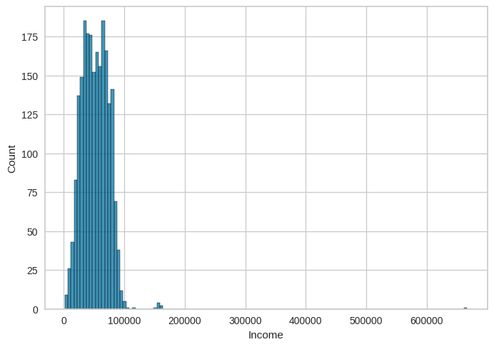

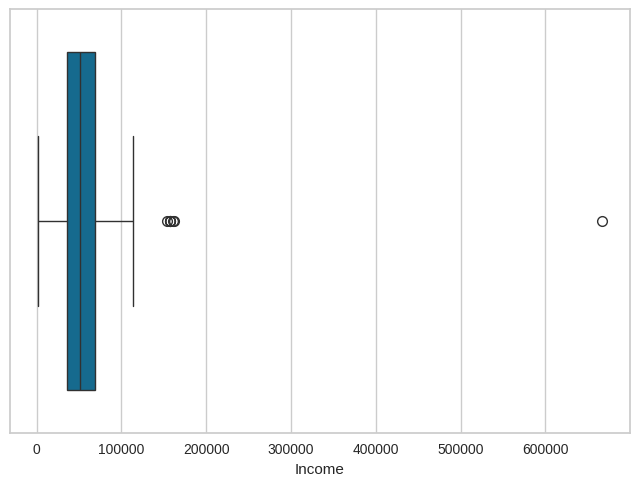

```
ID                     0
Year_Birth             0
Education              0
Marital_Status         0
Income                 0
Kidhome                0
Teenhome               0
Dt_Customer            0
Recency                0
MntWines               0
MntFruits              0
MntMeatProducts        0
MntFishProducts        0
MntSweetProducts       0
MntGoldProds           0
NumDealsPurchases      0
NumWebPurchases        0
NumCatalogPurchases    0
NumStorePurchases      0
NumWebVisitsMonth      0
AcceptedCmp3           0
AcceptedCmp4           0
AcceptedCmp5           0
AcceptedCmp1           0
AcceptedCmp2           0
Complain               0
Z_CostContact          0
Z_Revenue              0
Response               0
dtype: int64
```

```python
data.isnull().sum()
print(data.isnull().sum())
# There are 24 missing values in the "Income" column

#these plot will show the distribution so I can visualize the observations. Depending on the distribution, I will use either median or mean to replace the null values
sns.histplot(data = data, x = 'Income')
plt.show()

sns.boxplot(data = data, x = 'Income')
plt.show()

#Because there are outliers observed in the histogram and boxplots, I will replace the missing values with the median household income.
data['Income'] = data['Income'].fillna(value = data['Income'].median())
print(data.isnull().sum())
```

##### **Observations:**

#### **Question 4**: Are there any duplicates in the data?

```python
#this will give you the sum/total number of duplicated values
data.duplicated().sum()
```

```
np.int64(0)
```

##### **Observations:** There are no duplicates in the dataset

## **Exploratory Data Analysis**

### Univariate Analysis

#### **Question 5:** Explore all the variables and provide observations on their distributions. (histograms and boxplots)

```python
#I am going to convert year_birth to an age, so I can do a better analysis of it:
data['Age'] = datetime.now().year - data['Year_Birth']

#I am dropping some columns that I don't think will make much difference in the analysis, then checking the first few rows to ensure everything looks correct:
df = data.drop(columns=['ID', 'Year_Birth', 'Dt_Customer', 'Z_CostContact', 'Z_Revenue', 'AcceptedCmp1', 'AcceptedCmp2', 'AcceptedCmp3', 'AcceptedCmp4', 'AcceptedCmp5'])
df.head()
```

|  | Education | Marital_Status | Income | Kidhome | Teenhome | Recency | MntWines | MntFruits | MntMeatProducts | MntFishProducts | MntSweetProducts | MntGoldProds | NumDealsPurchases | NumWebPurchases | NumCatalogPurchases | NumStorePurchases | NumWebVisitsMonth | Complain | Response | Age |
| --- | --- | --- | --- | --- | --- | --- | --- | --- | --- | --- | --- | --- | --- | --- | --- | --- | --- | --- | --- | --- |
| 0 | Graduation | Single | 58138.0 | 0 | 0 | 58 | 635 | 88 | 546 | 172 | 88 | 88 | 3 | 8 | 10 | 4 | 7 | 0 | 1 | 68 |
| 1 | Graduation | Single | 46344.0 | 1 | 1 | 38 | 11 | 1 | 6 | 2 | 1 | 6 | 2 | 1 | 1 | 2 | 5 | 0 | 0 | 71 |
| 2 | Graduation | Together | 71613.0 | 0 | 0 | 26 | 426 | 49 | 127 | 111 | 21 | 42 | 1 | 8 | 2 | 10 | 4 | 0 | 0 | 60 |
| 3 | Graduation | Together | 26646.0 | 1 | 0 | 26 | 11 | 4 | 20 | 10 | 3 | 5 | 2 | 2 | 0 | 4 | 6 | 0 | 0 | 41 |
| 4 | PhD | Married | 58293.0 | 1 | 0 | 94 | 173 | 43 | 118 | 46 | 27 | 15 | 5 | 5 | 3 | 6 | 5 | 0 | 0 | 44 |

```python
#Converting complain and response columns from numeric to boolean because they are T/F or 1/0
df['Complain'] = df['Complain'].astype(bool)
df['Response'] = df['Response'].astype(bool)
df.info()
```

```
<class 'pandas.core.frame.DataFrame'>
RangeIndex: 2240 entries, 0 to 2239
Data columns (total 20 columns):
 #   Column               Non-Null Count  Dtype
---  ------               --------------  -----
 0   Education            2240 non-null   object
 1   Marital_Status       2240 non-null   object
 2   Income               2240 non-null   float64
 3   Kidhome              2240 non-null   int64
 4   Teenhome             2240 non-null   int64
 5   Recency              2240 non-null   int64
 6   MntWines             2240 non-null   int64
 7   MntFruits            2240 non-null   int64
 8   MntMeatProducts      2240 non-null   int64
 9   MntFishProducts      2240 non-null   int64
 10  MntSweetProducts     2240 non-null   int64
 11  MntGoldProds         2240 non-null   int64
 12  NumDealsPurchases    2240 non-null   int64
 13  NumWebPurchases      2240 non-null   int64
 14  NumCatalogPurchases  2240 non-null   int64
 15  NumStorePurchases    2240 non-null   int64
 16  NumWebVisitsMonth    2240 non-null   int64
 17  Complain             2240 non-null   bool
 18  Response             2240 non-null   bool
 19  Age                  2240 non-null   int64
dtypes: bool(2), float64(1), int64(15), object(2)
memory usage: 319.5+ KB
```

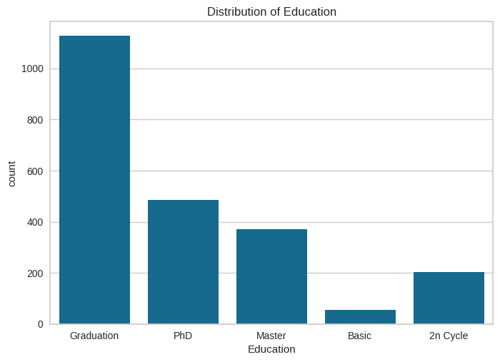

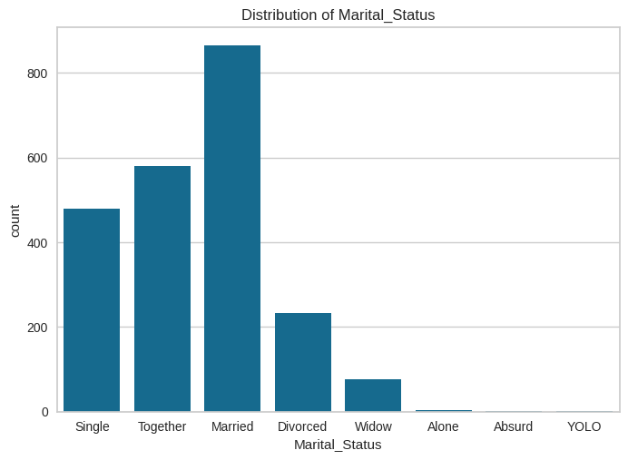

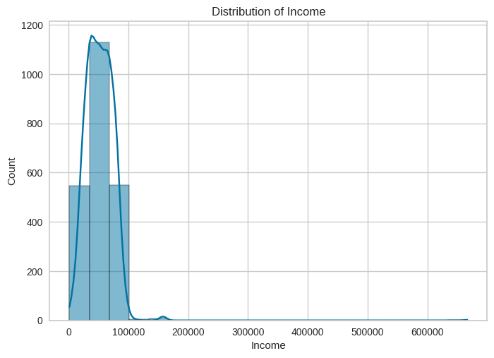

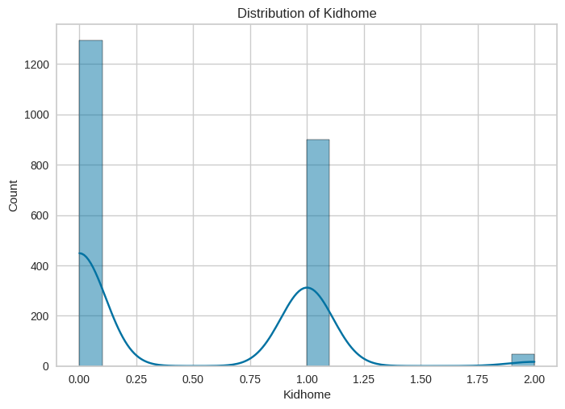

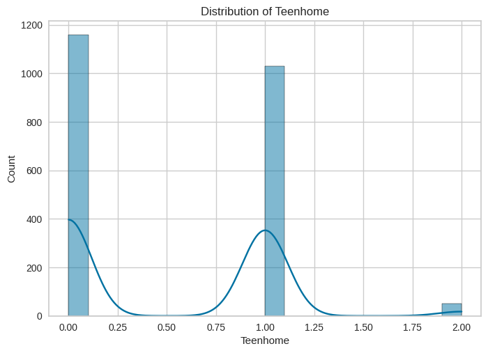

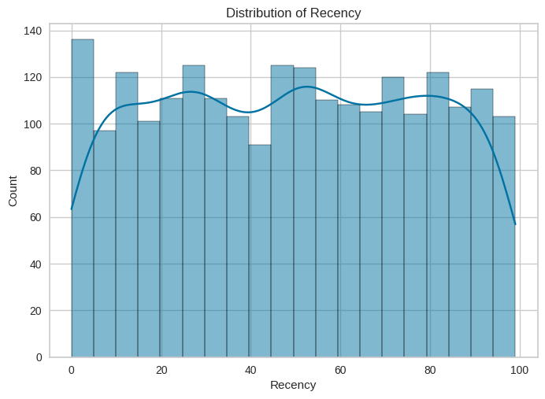

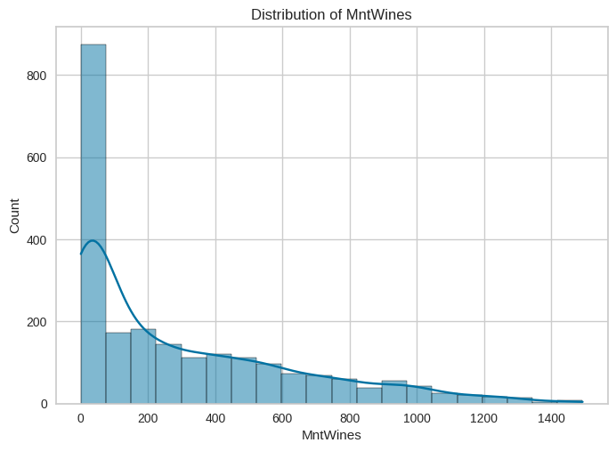

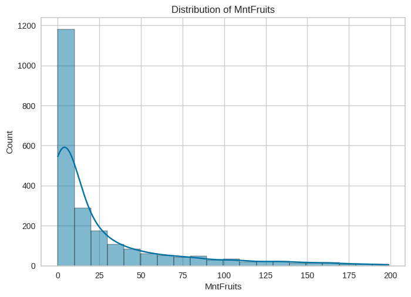

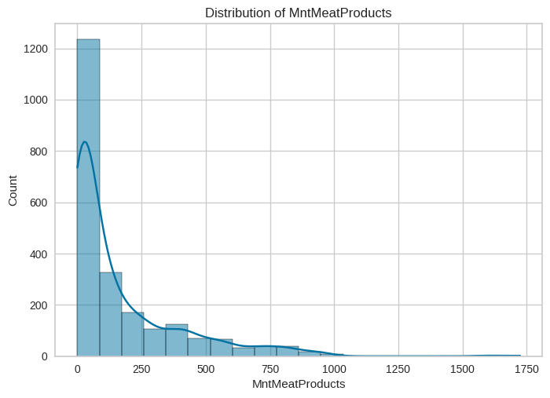

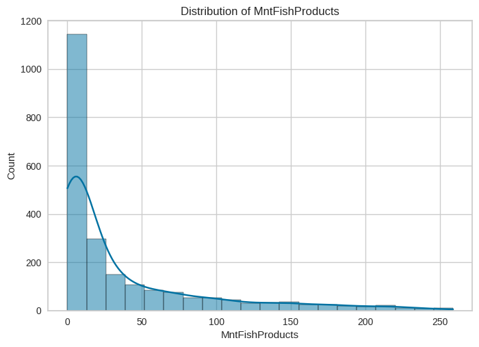

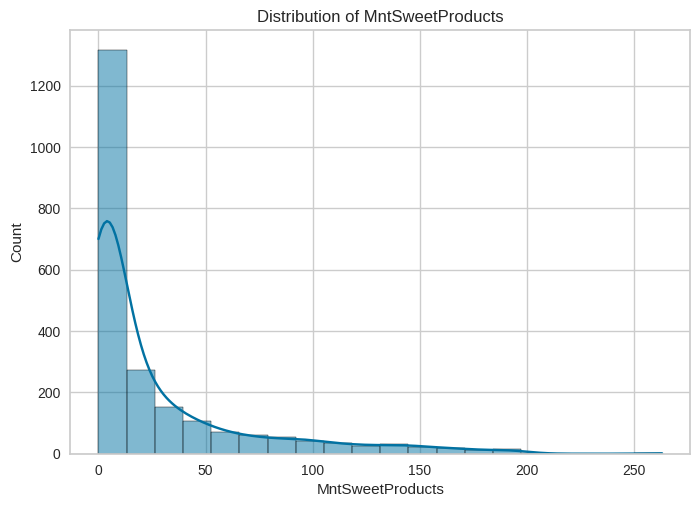

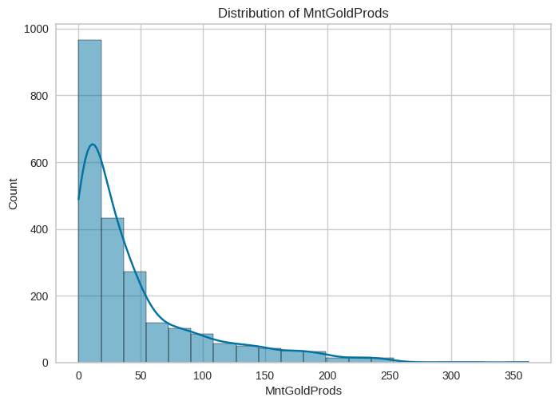

[22 more figures not shown]

```python
# I am using a count/bar plot for education and marital status because those variables are non-numeric and therefore cannot plot as a histogram:

for col in df.select_dtypes(include='object').columns:
    plt.figure()
    sns.countplot(data=df, x=col)
    plt.title(f'Distribution of {col}')
    plt.show()

#I am now plotting histograms of the numeric variables. I added kde=true to visualize the distributions a bit easier:

for col in df.select_dtypes(include='number').columns:
    plt.figure()
    sns.histplot(df[col], kde=True, bins=20)
    plt.title(f'Distribution of {col}')
    plt.show()

# Boxplots of numerical variables:

for col in df.select_dtypes(include='number').columns:
  plt.figure()
  sns.boxplot(x=df[col])
  plt.title(f'Boxplot of {col}')
  plt.show()
```

##### **Observations:**

Looking at the countplots - in terms of demographics, the majority of customers have "graduation" level education which I would want to clarify, but I assume refers to bachelors degree. Additionally, customers are primarily "married" or "together".

Analyzing the histograms - average age of approximately 55 years. Most people have income levels below $100,00, with a few outliers. Most customers don't have kids or teens at home or have 1 child/teen. The highest amount of items sold are sweets and meat, and people tend to spend more on wine and meat compared to the other categories. All of the distributions of amount spent on a category are skewed right, distribution of age and income are fairly normal with the exception of a few outliers in the population. The distribution of recency since purchasing is fairly uniform. Additionally, all of the distributions for number of catalog, instore, web purchases are generally skewed right.

```
    Education Marital_Status   Income  Kidhome  Teenhome  Recency  MntWines  \
192  2n Cycle       Divorced  36640.0        1         0       99        15
239  2n Cycle         Single  60182.0        0         1       23         8
339       PhD       Together  83532.0        0         0       36       755

     MntFruits  MntMeatProducts  MntFishProducts  MntSweetProducts  \
192          6                8                7                 4
239          0                5                7                 0
339        144              562              104                64

     MntGoldProds  NumDealsPurchases  NumWebPurchases  NumCatalogPurchases  \
192            25                  1                2                    1
239             2                  1                1                    0
339           224                  1                4                    6

     NumStorePurchases  NumWebVisitsMonth  Complain  Response  Age
192                  2                  5      True     False  125
239                  2                  4     False     False  132
339                  4                  1     False     False  126
```

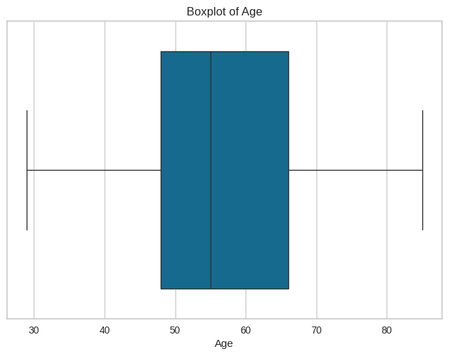

```python
# Due to the age outliers, I am going to view these outliers

print(df[df['Age'] > 100])

# We can now see that there are three observations with age 125, 132, and 126. Most likely this was entered incorrectly with an added 1, however I will convert these to median age
df['Age'] = df['Age'].replace([125, 132, 126], df['Age'].median())

# Now I want to recheck my age box plot, and now we do not see the outlier values:
plt.figure()
sns.boxplot(x=df['Age'])
plt.title(f'Boxplot of Age')
plt.show()
```

### Bivariate Analysis

#### **Question 6:** Perform multivariate analysis to explore the relationsips between the variables.

```python
#To do a multivariate analysis, I want to start by checking  the correlations between each variable

corr = df.corr(numeric_only = True).round(2)
print(corr)

#The above is difficult to make sense of, so I will now plot a heatmap to view the correlations

plt.figure(figsize=(12, 8)) #added this line to make the plot easier to view
sns.heatmap(corr, annot=True, vmin = -1, vmax = 1, cmap='coolwarm', fmt=".2f")
plt.title("Correlation Matrix")
plt.show()

#I am removing variables and creating a subset of the dataset with variables that appear more correlated
correlated_variables = df[['MntWines', 'Income', 'MntMeatProducts', 'MntFruits', 'NumCatalogPurchases', 'NumStorePurchases', 'NumWebVisitsMonth', 'NumWebPurchases', 'Kidhome', 'MntFishProducts', 'MntSweetProducts', 'Age']]

#Running another heatmap with the subset of variables ('correlated_variables')
sns.heatmap(correlated_variables.corr(), annot=True, cmap='coolwarm')
plt.show()

#Running a pairplot to view the correlations differently. Adding corner = True, to remove the duplicate plots to make viewing this easier.
sns.pairplot(data= correlated_variables, diag_kind="kde", corner = True)
plt.show()
```

```
Output hidden; open in https://colab.research.google.com to view.
```

##### **Observations:**

Income is positively correlated with mntmeatproducts, mntwine, and numstorepurchases at 0.58, 0.58 and 0.59, respectively, but is negatively correlated at -0.55 with numwebvisits. This indicates that higher income individuals tend to spend more on meat and wine and purchase these items in store compared to online.

When looking at web visits and web purchases, it seems that customers tend to spend more from catalog or in store.

Having a kid at home is negatively correlated with spending on wine, catalog and in store purchases.

Interestingly, age does not seem to be correlated with any other variables.

## **K-means Clustering**

#### **Question 7** : Select the appropriate number of clusters using the elbow Plot. What do you think is the appropriate number of clusters?

```python
#Scaling data to ensure values are standardized (using subset of data only)

scaler = StandardScaler()

data_scaled = pd.DataFrame(scaler.fit_transform(correlated_variables), columns=correlated_variables.columns)

data_scaled.head()
```

|  | MntWines | Income | MntMeatProducts | MntFruits | NumCatalogPurchases | NumStorePurchases | NumWebVisitsMonth | NumWebPurchases | Kidhome | MntFishProducts | MntSweetProducts | Age |
| --- | --- | --- | --- | --- | --- | --- | --- | --- | --- | --- | --- | --- |
| 0 | 0.983781 | 0.235696 | 1.679702 | 1.551577 | 2.510890 | -0.550785 | 0.693904 | 1.409304 | -0.825218 | 2.462147 | 1.476500 | 1.018098 |
| 1 | -0.870479 | -0.235454 | -0.713225 | -0.636301 | -0.568720 | -1.166125 | -0.130463 | -1.110409 | 1.032559 | -0.650449 | -0.631503 | 1.274694 |
| 2 | 0.362723 | 0.773999 | -0.177032 | 0.570804 | -0.226541 | 1.295237 | -0.542647 | 1.409304 | -0.825218 | 1.345274 | -0.146905 | 0.333842 |
| 3 | -0.870479 | -1.022355 | -0.651187 | -0.560857 | -0.910898 | -0.550785 | 0.281720 | -0.750450 | 1.032559 | -0.503974 | -0.583043 | -1.291266 |
| 4 | -0.389085 | 0.241888 | -0.216914 | 0.419916 | 0.115638 | 0.064556 | -0.130463 | 0.329427 | 1.032559 | 0.155164 | -0.001525 | -1.034670 |

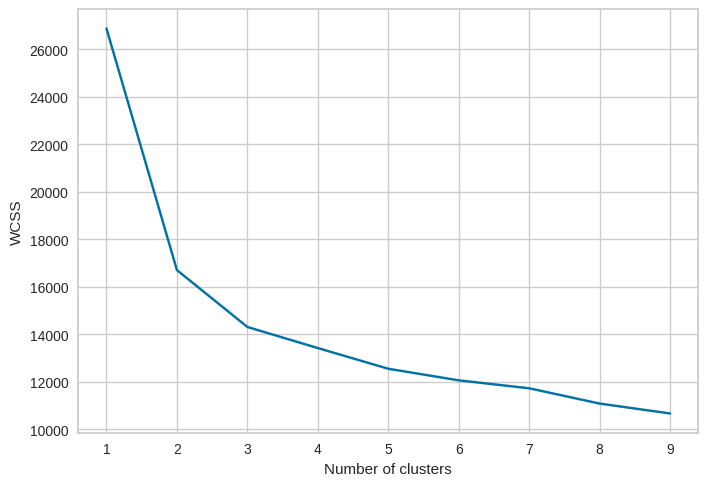

```python
#Creating elbow plot
# step 1 - creaing an empty dictionary to store the within-cluster sum of squares
WCSS = {}

# step 2 - iterate for a range of K clusters (from 1-9) for the scaled data. kmeans.inertia_ stores the values of the WCSS for each cluster. I added random_state so that iteration will start at the same point each time it is run.
for k in range(1, 10):
    kmeans = KMeans(n_clusters=k, max_iter=1000, random_state=1)
    kmeans.fit(data_scaled)
    WCSS[k] = kmeans.inertia_

# step 3 - here we plot the within cluster sum of squares versus cluster size. To find optimal clusters you find the point at which there is the sharpest curve (i.e. the elbow)
plt.figure()
plt.plot(list(WCSS.keys()), list(WCSS.values()), 'bx-')
plt.xlabel("Number of clusters")
plt.ylabel("WCSS")
plt.show()
```

##### **Observations:**

Using the elbow method above, it appears that the optimal number of clusters is 2 or 3. Since the drop off is steeper at 2 clusters, I would begin with that number.

#### **Question 8** : finalize appropriate number of clusters by checking the silhoutte score as well. Is the answer different from the elbow plot?

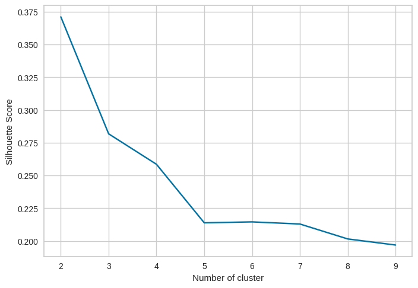

```python
#Empty dictionary to store the Silhouette score for each value of k
sc = {}

# iterate for a range of K clusters from 2-9 (cannot run this with 1 cluster) and fit the scaled data. Store the Silhouette score for that k
for k in range(2, 10):
    kmeans = KMeans(n_clusters=k, random_state=1).fit(data_scaled)
    labels = kmeans.predict(data_scaled)
    sc[k] = silhouette_score(data_scaled, labels)

#Elbow plot of silhouette score versus number of clusters
plt.figure()
plt.plot(list(sc.keys()), list(sc.values()), 'bx-')
plt.xlabel("Number of cluster")
plt.ylabel("Silhouette Score")
plt.show()
```

```python
# Here we are creating a new dataframe and saving the original column names in it. After scaling the data, the original column names can be lost.
original_column_names = data_scaled.columns
data_scaled_df = pd.DataFrame(data_scaled, columns=original_column_names)

# Fit and assign cluster labels using 3 clusters
kmeans_final = KMeans(n_clusters=3, random_state=1)
kmeans_final.fit(data_scaled)

#adding labels and assigning each row/observation to one of three clusters
data_scaled_df['Labels'] = kmeans_final.predict(data_scaled)

# storing cluster labels separately
cluster_labels = kmeans_final.predict(data_scaled)
```

## **Cluster Profiling and Comparison**

#### **Question 10**: Perform cluster profiling using boxplots for the K-Means algorithm. Analyze key characteristics of each cluster and provide detailed observations.

```python
#This takes the new dataframe and finding number of observations in each cluster
data_scaled_df.Labels.value_counts()
```

| Labels | count |
| --- | --- |
| 1 | 1043 |
| 0 | 635 |
| 2 | 562 |

**dtype:** int64

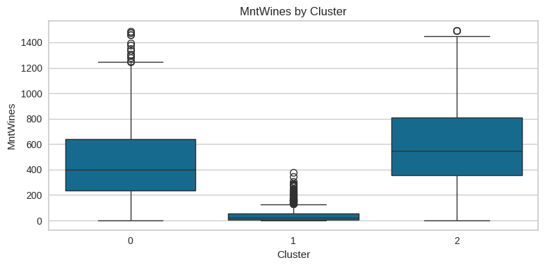

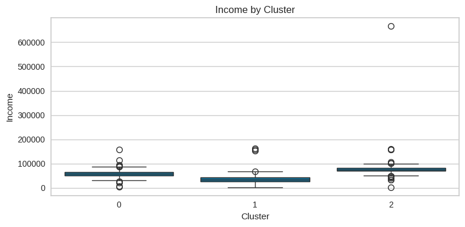

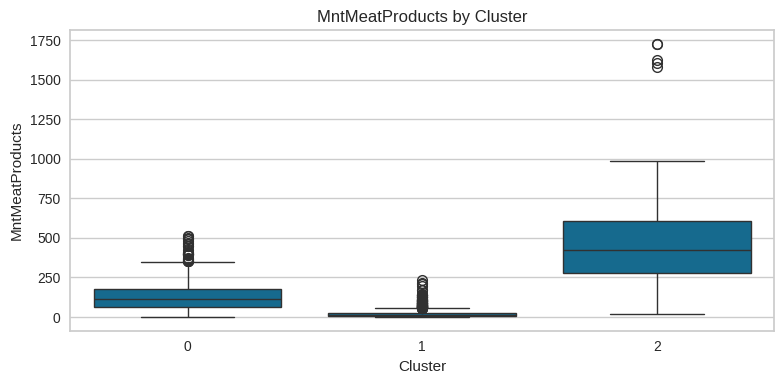

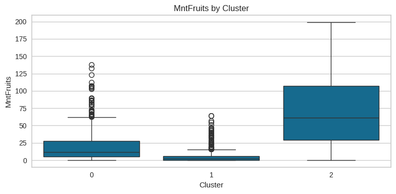

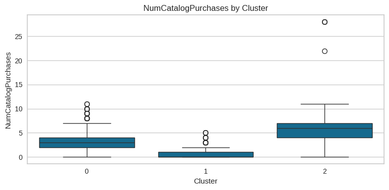

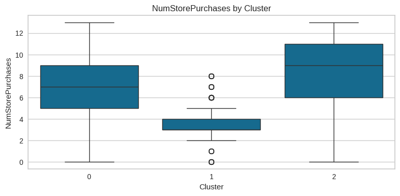

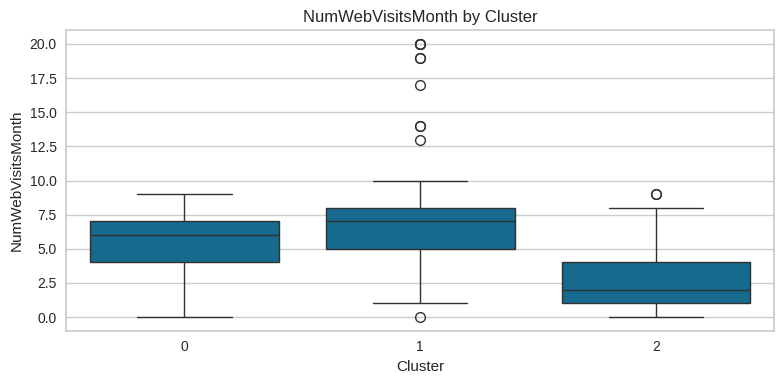

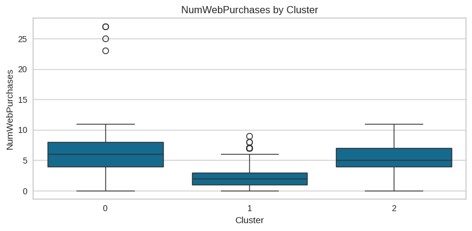

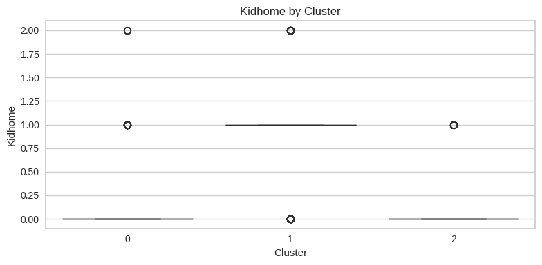

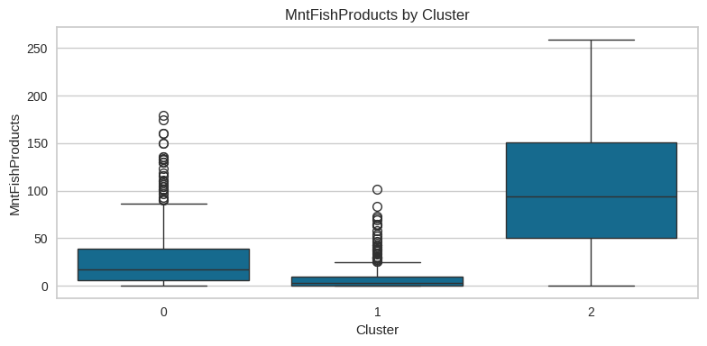

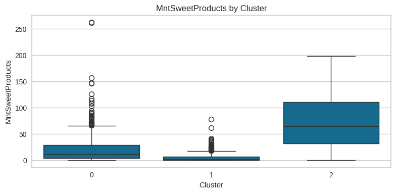

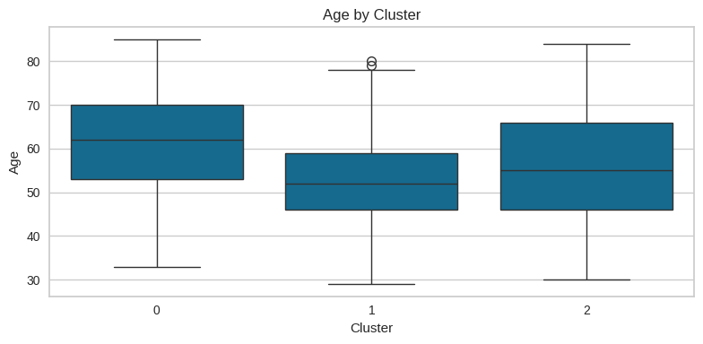

```python
#adding cluster labels as a new column to original data
correlated_variables['Cluster'] = kmeans_final.labels_

#selecting only numeric variables to plot
features = correlated_variables.select_dtypes(include='number').drop(columns='Cluster').columns

# Create boxplots for each feature/column
for col in features:
    plt.figure(figsize=(8, 4))
    sns.boxplot(x='Cluster', y=col, data=correlated_variables)
    plt.title(f'{col} by Cluster')
    plt.xlabel('Cluster')
    plt.ylabel(col)
    plt.tight_layout()
    plt.show()
```

##### **Observations:**

There are three groups labeled 0, 1, 2 with 635, 1043, and 562 observations in each, respectively. Group 2 is your higher income cluster and group 1 is your lower income cluster. You can see that the higher income cluster tends to spend more in all categories (sweets, fish, fruit, meat and wine), however there appears to be more outliers in group 0 and 1.

Interestingly, cluster 1 has the highest number of web visits per month, but have the lowest number of web purchases among the clusters. Potentially, this could indicate that they are browsing and comparing prices/deals to other stores. This group also has the lowest number of in store purchase, which in conjunction to the web browsing data may indicate that this group is purchasing elsewhere because our prices are too high for them.

Lastly, it appears that cluster 1 has more children at home and with the lower income group, and this makes sense as this cluster also has the lowest median age.